# Tree History

### Tree History

**Authored by:** Venuka Hirushan Wijenayake

**Date:** T1 2024 (March - July)

**Duration:** 270 mins

**Level:** Beginner/ Intermediate

**Pre-requisite Skills:** Python, Power BI, Machine Learning

### Scenario

**As a** member of the local city council's urban planning department,

**I want to** conduct a comprehensive analysis of the diversity of tree species within the Melbourne area, comparing the current variety and density of tree species to historical data from pre-colonial times,

**So that I can** identify significant changes and trends in tree diversity over time, specifically pinpointing species that have become less common or are on the verge of disappearing from the local ecosystem.

**This will help** in making informed decisions about which species to prioritize in future tree planting programs, aiming to restore ecological balance, enhance urban biodiversity, and support sustainable urban development.

### Skills Demonstrated in the Tree Mapping Project

##### 1. Geospatial Analysis

- - Data Manipulation: Utilized Pandas and GeoPandas for transforming and preparing spatial data, crucial for mapping and analysis.
  - Spatial Visualization: Employed Folium to create interactive maps that visualize geographic data, enhancing the understanding of spatial distribution and density of tree plantations.

##### 5. Communication and Presentation

- - Clear Data Presentation: Designed maps that are not only functional but also user-friendly, ensuring that complex data is accessible and understandable to a broad audience.
  - Documentation and Reporting: Crafted well-documented code and prepared comprehensive reports that explain the methodology, tools used, and insights derived from the data.

These skills are indicative of a well-rounded ability to handle, analyze, and present geospatial data in a manner that supports urban planning and environmental analysis, demonstrating both technical proficiency and analytical acumen.

### Project Goal: Melbourne Tree Species Analysis for Conservation Effort

Conduct an in-depth analysis of the range of tree species in the Melbourne area, comparing historical data from pre-colonial times with current records. This study aims to identify changes in tree diversity, highlighting species that have diminished in numbers or variety. The ultimate goal is to provide evidence-based recommendations to local councils for tree planting programs, prioritizing species that need increased numbers to restore ecological balance and enhance urban biodiversity.

#### Key Activities

- Historical Data Collection: Gather and analyze historical records and indigenous knowledge to identify the pre-colonial tree species composition.
- Current Species Survey: Utilize current botanical surveys, remote sensing data, and council records to compile an up-to-date list of tree species within Melbourne.
- Comparative Analysis: Compare historical and current data to identify trends, losses, or gains in tree species diversity.
- Recommendation Development: Based on the analysis, recommend tree species that need conservation focus and increased numbers in planting programs.

#### Expected Outcome

A comprehensive report detailing changes in Melbourne's tree species over time, with actionable recommendations for local councils to inform future tree planting initiatives, aiming to restore lost tree species and enhance urban green spaces.

#### Impact

This project not only contributes to the conservation of Melbourne's botanical heritage but also supports urban sustainability efforts. By informing council tree planting programs with a focus on biodiversity, we can work towards a greener, more resilient Melbourne for future generations.

#### Datasets

*1. Trees, with species and dimensions (Urban Forest)*  
[Link to Dataset 1](https://data.melbourne.vic.gov.au/explore/dataset/trees-with-species-and-dimensions-urban-forest/information/)

*2. Pre-colonial plant list*  
[Link to Dataset 2](https://data.melbourne.vic.gov.au/explore/dataset/pre-colonial-plant-list/information/)

## Installing all necessasory packages (optional)

```python
# !pip install requests pandas matplotlib-venn folium geopandas seaborn statsmodels
```

## Importing all the necessory libraries

```python
import requests
import pandas as pd
import os
from matplotlib_venn import venn2
import matplotlib.pyplot as plt
import folium
from folium.plugins import MarkerCluster, FeatureGroupSubGroup
import geopandas as gpd
import seaborn as sns
import matplotlib.pyplot as plt
from statsmodels.tsa.stattools import adfuller
from statsmodels.tsa.arima.model import ARIMA
import warnings
warnings.filterwarnings('ignore')
```

## Importing datasets

```python
def fetch_data(base_url, dataset, api_key, num_records=99, offset=0):
    all_records = []
    max_offset = 9900  # Maximum number of requests

    while True:
        # maximum limit check
        if offset > max_offset:
            break

        # Create API request URL
        filters = f'{dataset}/records?limit={num_records}&offset={offset}'
        url = f'{base_url}{filters}&api_key={api_key}'

        # Start request
        try:
            result = requests.get(url, timeout=10)
            result.raise_for_status()
            records = result.json().get('results')
        except requests.exceptions.RequestException as e:
            raise Exception(f"API request failed: {e}")
        if records is None:
            break
        all_records.extend(records)
        if len(records) < num_records:
            break

        # next cycle offset
        offset += num_records

    # DataFrame all data
    df = pd.DataFrame(all_records)
    return df

API_KEY = os.environ.get("API_KEY ")
# print("API Key:", API_KEY)
BASE_URL = 'https://data.melbourne.vic.gov.au/api/explore/v2.1/catalog/datasets/'
```

```python
# data set name
PRE_COLONIAL_TREES = 'pre-colonial-plant-list'

pre_colonial_trees = fetch_data(BASE_URL, PRE_COLONIAL_TREES, API_KEY)

pre_colonial_trees
```

|  | species | common_name_s | certain | beach_and_dunes | saltmarsh | coastal_marshlands_and_brackish_flats | swamp_scrub | woodlands_and_heathlands_on_sand | woodlands_and_forests_on_sedimentary_hills_valleys_and_ridges | grasslands_and_woodlands_on_fertile_plains | cliffs_and_escarpments | river_banks_and_creeklines | wet_heathland | freshwater_wetland | saltwater_wetland | most_likely_occurrence | epbc_category_of_threat | ffg_extinction_risk | ffg_category_of_threat |
| --- | --- | --- | --- | --- | --- | --- | --- | --- | --- | --- | --- | --- | --- | --- | --- | --- | --- | --- | --- |
| 0 | Acacia mucronata var. longifolia | Narrow-leaf Wattle, Variable Sallow Wattle | NaN | 0.0 | 0.0 | 0.0 | 0.0 | 0.0 | 1.0 | 0.0 | 0.0 | 0.0 | 0.0 | 0.0 | 0 | 1.0 | None | None | None |
| 1 | Acacia pycnantha | Golden Wattle | 1.0 | 0.0 | 0.0 | 0.0 | 1.0 | 2.1 | 3.2 | 3.1 | 2.1 | 2.1 | 0.0 | 0.0 | 0 | 3.2 | None | None | None |
| 2 | Acacia verticillata var. verticillata | Prickly Moses | NaN | 0.0 | 0.0 | 0.0 | 3.1 | 3.1 | 0.0 | 0.0 | 0.0 | 3.1 | 1.0 | 0.0 | 0 | 3.1 | None | None | None |
| 3 | Acaena echinata | Sheep's Burr | 1.0 | 0.0 | 0.0 | 0.0 | 0.0 | 1.0 | 3.1 | 3.1 | 3.1 | 2.1 | 0.0 | 0.0 | 0 | 3.1 | None | None | None |
| 4 | Acrotriche prostrata | Trailing Ground-Berry | NaN | 0.0 | 0.0 | 0.0 | 0.0 | 0.0 | 1.0 | 0.0 | 0.0 | 0.0 | 0.0 | 0.0 | 0 | 1.0 | None | None | None |
| ... | ... | ... | ... | ... | ... | ... | ... | ... | ... | ... | ... | ... | ... | ... | ... | ... | ... | ... | ... |
| 1062 | Xanthorrhoea minor subsp. lutea | Small Grass Tree, Toolimerin | NaN | 0.0 | 0.0 | 0.0 | 0.0 | 2.1 | 1.0 | 0.0 | 0.0 | 0.0 | 0.0 | 0.0 | 0 | 2.1 | None | None | None |
| 1063 | Xerochrysum bracteatum | Golden Everlasting, Straw Flower | NaN | 0.0 | 0.0 | 0.0 | 0.0 | 1.0 | 0.0 | 0.0 | 0.0 | 0.0 | 0.0 | 0.0 | 0 | 1.0 | None | None | None |
| 1064 | Zostera muelleri subsp. capricorni | Eel-grass | NaN | 0.0 | 0.0 | 0.0 | 0.0 | 0.0 | 0.0 | 0.0 | 0.0 | 0.0 | 0.0 | 0.0 | 3 | 3.2 | None | None | None |
| 1065 | Zostera muelleri subsp. muelleri | Dwarf Grass-wrack | NaN | 0.0 | 0.0 | 0.0 | 0.0 | 0.0 | 0.0 | 0.0 | 0.0 | 0.0 | 0.0 | 0.0 | 2 | 2.2 | None | None | None |
| 1066 | Zygophyllum billardierei | Coast Twinleaf | NaN | 2.1 | 0.0 | 0.0 | 0.0 | 0.0 | 0.0 | 0.0 | 0.0 | 0.0 | 0.0 | 0.0 | 0 | 2.1 | None | None | None |

1067 rows × 19 columns

```python
# data set name
CURRENT_TREES = 'trees-with-species-and-dimensions-urban-forest'

current_trees = fetch_data(BASE_URL, CURRENT_TREES, API_KEY)

current_trees
```

|  | com_id | common_name | scientific_name | genus | family | diameter_breast_height | year_planted | date_planted | age_description | useful_life_expectency | useful_life_expectency_value | precinct | located_in | uploaddate | coordinatelocation | latitude | longitude | easting | northing | geolocation |
| --- | --- | --- | --- | --- | --- | --- | --- | --- | --- | --- | --- | --- | --- | --- | --- | --- | --- | --- | --- | --- |
| 0 | 1546404 | River Sheoak | Casuarina cunninghamiana | Casuarina | Casuarinaceae | NaN | 2013 | 2013-01-07 | None | None | NaN | None | Park | 2021-01-10 | {'lon': 144.97177997020128, 'lat': -37.8180699... | -37.818070 | 144.971780 | 321479.34 | 5812432.31 | {'lon': 144.97177997020128, 'lat': -37.8180699... |
| 1 | 1038666 | Claret Ash | Fraxinus angustifolia subsp. oxycarpa | Fraxinus | Oleaceae | 26.0 | 1998 | 1998-11-09 | Semi-Mature | 11-20 years | 20.0 | None | Park | 2021-01-10 | {'lon': 144.96069216093832, 'lat': -37.7815772... | -37.781577 | 144.960692 | 320414.93 | 5816460.51 | {'lon': 144.96069216093832, 'lat': -37.7815772... |
| 2 | 1439845 | Kanooka | Tristaniopsis laurina | Tristaniopsis | Myrtaceae | NaN | 2009 | 2009-09-08 | None | None | NaN | None | Street | 2021-01-10 | {'lon': 144.9455194257097, 'lat': -37.79259845... | -37.792598 | 144.945519 | 319105.53 | 5815208.27 | {'lon': 144.9455194257097, 'lat': -37.79259845... |
| 3 | 1070962 | Spotted Gum | Corymbia maculata | Corymbia | Myrtaceae | 17.0 | 2007 | 2007-06-14 | Semi-Mature | 31-60 years | 60.0 | None | Street | 2021-01-10 | {'lon': 144.9421772126995, 'lat': -37.78013819... | -37.780138 | 144.942177 | 318780.78 | 5816584.46 | {'lon': 144.9421772126995, 'lat': -37.78013819... |
| 4 | 1066252 | River red gum | Eucalyptus camaldulensis | Eucalyptus | Myrtaceae | 19.0 | 2006 | 2006-02-20 | Semi-Mature | 61+ years | 80.0 | None | Street | 2021-01-10 | {'lon': 144.92039340703647, 'lat': -37.7905765... | -37.790577 | 144.920393 | 316887.98 | 5815383.70 | {'lon': 144.92039340703647, 'lat': -37.7905765... |
| ... | ... | ... | ... | ... | ... | ... | ... | ... | ... | ... | ... | ... | ... | ... | ... | ... | ... | ... | ... | ... |
| 9994 | 1066718 | Yellow Box | Eucalyptus melliodora | Eucalyptus | Myrtaceae | NaN | 2006 | 2006-09-14 | None | None | NaN | None | Park | 2021-01-10 | {'lon': 144.9546546149572, 'lat': -37.78488602... | -37.784886 | 144.954655 | 319891.23 | 5816081.73 | {'lon': 144.9546546149572, 'lat': -37.78488602... |
| 9995 | 1735402 | Manuka | Kunzea ericoides | Kunzea | Myrtaceae | NaN | 2018 | 2018-05-30 | None | None | NaN | None | Park | 2021-01-10 | {'lon': 144.9514066985289, 'lat': -37.79316880... | -37.793169 | 144.951407 | 319625.34 | 5815156.36 | {'lon': 144.9514066985289, 'lat': -37.79316880... |
| 9996 | 1656707 | Norfolk Island Pine | Araucaria heterophylla | Araucaria | Araucariaceae | NaN | 2017 | 2017-04-26 | None | None | NaN | None | Street | 2021-01-10 | {'lon': 144.9471755893213, 'lat': -37.81988993... | -37.819890 | 144.947176 | 319317.91 | 5812183.04 | {'lon': 144.9471755893213, 'lat': -37.81988993... |
| 9997 | 1604462 | Lightwood Wattle | Acacia implexa | Acacia | Fabaceae | NaN | 2015 | 2015-08-25 | None | None | NaN | None | Park | 2021-01-10 | {'lon': 144.9524311587096, 'lat': -37.79529060... | -37.795291 | 144.952431 | 319720.71 | 5814922.89 | {'lon': 144.9524311587096, 'lat': -37.79529060... |
| 9998 | 1049080 | River red gum | Eucalyptus camaldulensis | Eucalyptus | Myrtaceae | NaN | 1998 | 1998-12-16 | None | None | NaN | None | Park | 2021-01-10 | {'lon': 144.94552257177912, 'lat': -37.7903449... | -37.790345 | 144.945523 | 319100.31 | 5815458.34 | {'lon': 144.94552257177912, 'lat': -37.7903449... |

9999 rows × 20 columns

## Preprocess the Data

### Displaying Available Columns

```python
# Print available columns in the pre-colonial trees cleaned dataset
print("Available columns in pre-colonial trees dataset:")
print(pre_colonial_trees.columns.tolist())

# Print available columns in the current trees cleaned dataset
print("\nAvailable columns in current trees dataset:")
print(current_trees.columns.tolist())
```

```
Available columns in pre-colonial trees dataset:
['species', 'common_name_s', 'certain', 'beach_and_dunes', 'saltmarsh', 'coastal_marshlands_and_brackish_flats', 'swamp_scrub', 'woodlands_and_heathlands_on_sand', 'woodlands_and_forests_on_sedimentary_hills_valleys_and_ridges', 'grasslands_and_woodlands_on_fertile_plains', 'cliffs_and_escarpments',…

Available columns in current trees dataset:
['com_id', 'common_name', 'scientific_name', 'genus', 'family', 'diameter_breast_height', 'year_planted', 'date_planted', 'age_description', 'useful_life_expectency', 'useful_life_expectency_value', 'precinct', 'located_in', 'uploaddate', 'coordinatelocation', 'latitude', 'longitude', 'easting', 'no…
```

### Removing unwanted columns

```python
# Columns to remove from the pre-colonial dataset
columns_to_remove_pre_colonial = ['epbc_category_of_threat', 'ffg_extinction_risk', 'ffg_category_of_threat', 'certain']

# Removing the specified columns from the pre-colonial trees dataset
pre_colonial_trees_cleaned = pre_colonial_trees.drop(columns=columns_to_remove_pre_colonial)

# Print available columns in the pre-colonial trees cleaned dataset after removal
print("Available columns in pre-colonial trees dataset after removal:")
print(pre_colonial_trees_cleaned.columns.tolist())

# Columns to remove from the current trees dataset
columns_to_remove_current = ['age_description', 'useful_life_expectency', 'useful_life_expectency_value', 'precinct', 'diameter_breast_height', 'coordinatelocation', 'easting', 'northing', 'geolocation']

# Removing the specified columns from the current trees dataset
current_trees_cleaned = current_trees.drop(columns=columns_to_remove_current)

# Print available columns in the current trees cleaned dataset after removal
print("\nAvailable columns in current trees dataset after removal:")
print(current_trees_cleaned.columns.tolist())
```

```
Available columns in pre-colonial trees dataset after removal:
['species', 'common_name_s', 'beach_and_dunes', 'saltmarsh', 'coastal_marshlands_and_brackish_flats', 'swamp_scrub', 'woodlands_and_heathlands_on_sand', 'woodlands_and_forests_on_sedimentary_hills_valleys_and_ridges', 'grasslands_and_woodlands_on_fertile_plains', 'cliffs_and_escarpments', 'river_ban…

Available columns in current trees dataset after removal:
['com_id', 'common_name', 'scientific_name', 'genus', 'family', 'year_planted', 'date_planted', 'located_in', 'uploaddate', 'latitude', 'longitude']
```

### Printing Available Columns after Removing Unwanted Columns

```python
# Print available columns in the pre-colonial trees cleaned dataset
print("Available columns in pre-colonial trees dataset:")
print(pre_colonial_trees_cleaned.columns.tolist())

# Print available columns in the current trees cleaned dataset
print("\nAvailable columns in current trees dataset:")
print(current_trees_cleaned.columns.tolist())
```

```
Available columns in pre-colonial trees dataset:
['species', 'common_name_s', 'beach_and_dunes', 'saltmarsh', 'coastal_marshlands_and_brackish_flats', 'swamp_scrub', 'woodlands_and_heathlands_on_sand', 'woodlands_and_forests_on_sedimentary_hills_valleys_and_ridges', 'grasslands_and_woodlands_on_fertile_plains', 'cliffs_and_escarpments', 'river_ban…

Available columns in current trees dataset:
['com_id', 'common_name', 'scientific_name', 'genus', 'family', 'year_planted', 'date_planted', 'located_in', 'uploaddate', 'latitude', 'longitude']
```

### Renaming Columns to Match Datasets

```python
# Rename "Scientific Name" column to "Species" in the current trees dataset
current_trees_renamed = current_trees_cleaned.rename(columns={"scientific_name": "species"})

# Verify the column renaming by printing the columns of the updated DataFrame
print("Available columns in current trees dataset after renaming:")
print(current_trees_renamed.columns.tolist())
```

```
Available columns in current trees dataset after renaming:
['com_id', 'common_name', 'species', 'genus', 'family', 'year_planted', 'date_planted', 'located_in', 'uploaddate', 'latitude', 'longitude']
```

## Analysis & Visualization

```python
current_trees_renamed
```

|  | com_id | common_name | species | genus | family | year_planted | date_planted | located_in | uploaddate | latitude | longitude |
| --- | --- | --- | --- | --- | --- | --- | --- | --- | --- | --- | --- |
| 0 | 1546404 | River Sheoak | Casuarina cunninghamiana | Casuarina | Casuarinaceae | 2013 | 2013-01-07 | Park | 2021-01-10 | -37.818070 | 144.971780 |
| 1 | 1038666 | Claret Ash | Fraxinus angustifolia subsp. oxycarpa | Fraxinus | Oleaceae | 1998 | 1998-11-09 | Park | 2021-01-10 | -37.781577 | 144.960692 |
| 2 | 1439845 | Kanooka | Tristaniopsis laurina | Tristaniopsis | Myrtaceae | 2009 | 2009-09-08 | Street | 2021-01-10 | -37.792598 | 144.945519 |
| 3 | 1070962 | Spotted Gum | Corymbia maculata | Corymbia | Myrtaceae | 2007 | 2007-06-14 | Street | 2021-01-10 | -37.780138 | 144.942177 |
| 4 | 1066252 | River red gum | Eucalyptus camaldulensis | Eucalyptus | Myrtaceae | 2006 | 2006-02-20 | Street | 2021-01-10 | -37.790577 | 144.920393 |
| ... | ... | ... | ... | ... | ... | ... | ... | ... | ... | ... | ... |
| 9994 | 1066718 | Yellow Box | Eucalyptus melliodora | Eucalyptus | Myrtaceae | 2006 | 2006-09-14 | Park | 2021-01-10 | -37.784886 | 144.954655 |
| 9995 | 1735402 | Manuka | Kunzea ericoides | Kunzea | Myrtaceae | 2018 | 2018-05-30 | Park | 2021-01-10 | -37.793169 | 144.951407 |
| 9996 | 1656707 | Norfolk Island Pine | Araucaria heterophylla | Araucaria | Araucariaceae | 2017 | 2017-04-26 | Street | 2021-01-10 | -37.819890 | 144.947176 |
| 9997 | 1604462 | Lightwood Wattle | Acacia implexa | Acacia | Fabaceae | 2015 | 2015-08-25 | Park | 2021-01-10 | -37.795291 | 144.952431 |
| 9998 | 1049080 | River red gum | Eucalyptus camaldulensis | Eucalyptus | Myrtaceae | 1998 | 1998-12-16 | Park | 2021-01-10 | -37.790345 | 144.945523 |

9999 rows × 11 columns

### 1. Historical vs. Current Species Diversity (Venn Diagram)

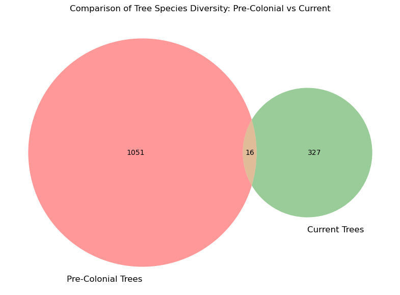

```python
# Extracting species lists from both datasets
pre_colonial_species = set(pre_colonial_trees_cleaned['species'].unique())
current_species = set(current_trees_renamed['species'].unique())

# Creating the Venn diagram
plt.figure(figsize=(10, 7))
venn2([pre_colonial_species, current_species], ('Pre-Colonial Trees', 'Current Trees'))
plt.title('Comparison of Tree Species Diversity: Pre-Colonial vs Current')
plt.show()
```

### Historical vs. Current Species Diversity (Venn Diagram)

This Venn diagram visually compares the diversity of tree species from pre-colonial times to the present day within Melbourne. The diagram's left circle represents species recorded historically, while the right circle shows species currently found in urban areas.

**Insights**:

- **Unique Historical Species**: The left exclusive area (Count of 1051) indicates species that were present historically but are no longer found, highlighting potential extinctions or migrations.
- **Unique Current Species**: The right exclusive area (Count of 327) shows species that are newly recorded, reflecting introductions or recent naturalizations in the urban environment.
- **Shared Species**: The intersection (Count of 16) represents species that have persisted through time, indicating resilience or stable ecological niches.

This analysis helps identify priority species for conservation efforts and guides future tree planting initiatives to enhance biodiversity and ecological stability in Melbourne's urban landscape.

### 2. Change in Species Abundance Over Time

```python
# Extract species sets
pre_colonial_species = set(pre_colonial_trees_cleaned['species'].unique())
current_species = set(current_trees_renamed['species'].unique())

# Determine shared and unique species
shared_species = pre_colonial_species.intersection(current_species)
lost_species = pre_colonial_species.difference(current_species)
gained_species = current_species.difference(pre_colonial_species)

# Print results
print(f"Shared Species: {len(shared_species)}")
print(f"Lost Species: {len(lost_species)}")
print(f"Gained Species: {len(gained_species)}")
```

```
Shared Species: 16
Lost Species: 1051
Gained Species: 327
```

## Change in Species Abundance Over Time

This section analyzes the shifts in species abundance over specified time periods, identifying trends in species gains and losses. This information is crucial for assessing the impacts of urban development and environmental changes on local biodiversity.

**Insights**:

- **Species Gained**: 327 species were gained over time, possibly due to new planting policies or ecological changes.
- **Species Lost**: 1051 species were lost over toime, which might indicate negative impacts like habitat loss or climate change.
- **Species Shared**: 16 species were found to be exsisting over time.

Understanding these trends allows city planners and conservationists to make informed decisions on which tree species need protective measures and which might be suitable for future planting.

### 3. Geographical Distribution of Trees (Map Visualization)

```python
# Convert DataFrame to GeoDataFrame
gdf = gpd.GeoDataFrame(
    current_trees_renamed,
    geometry=gpd.points_from_xy(current_trees_renamed.longitude, current_trees_renamed.latitude),
    crs="EPSG:4326"
)

# Initialize a map centered around Melbourne
melbourne_map = folium.Map(location=[-37.8136, 144.9631], zoom_start=12)

# Use MarkerCluster to manage multiple markers
marker_cluster = MarkerCluster().add_to(melbourne_map)

# Create FeatureGroupSubGroups for parks and streets within the MarkerCluster
park_group = FeatureGroupSubGroup(marker_cluster, 'Parks')
street_group = FeatureGroupSubGroup(marker_cluster, 'Streets')
park_group.add_to(melbourne_map)
street_group.add_to(melbourne_map)

# Add markers to the appropriate subgroup based on their location
for idx, row in gdf.iterrows():
    marker = folium.CircleMarker(
        location=[row.geometry.y, row.geometry.x],
        radius=3,
        color='green' if row['located_in'] == 'Park' else 'red',
        fill=True,
        fill_color='green' if row['located_in'] == 'Park' else 'red',
        popup=f"Species: {row['species']}, Planted: {row['date_planted']}"
    )
    if row['located_in'] == 'Park':
        marker.add_to(park_group)
    else:
        marker.add_to(street_group)

# Add LayerControl to toggle parks and streets
folium.LayerControl().add_to(melbourne_map)

# Display the map
melbourne_map
```

Make this Notebook Trusted to load map: File -> Trust Notebook

[interactive chart not shown]

### Geographical Distribution of Trees (Map Visualization)

This map provides a detailed view of the geographical distribution of tree species across Melbourne. It uses interactive features to allow users to explore different regions and understand the density and diversity of urban forestry. Further, the users would be able to filter the tree plantations based on their location, whether they are planted in the Streets or Parks.

**Map Details**:

This visualization aids in identifying areas with high or low species diversity, which is essential for planning future green spaces and conservation zones.

### 4. Time-Series Analysis of Tree Planting

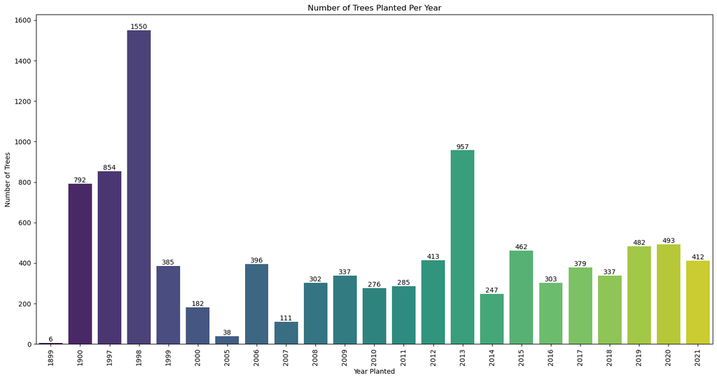

```python
# Ensure the 'year_planted' column is treated as integers
current_trees_renamed['year_planted'] = pd.to_numeric(current_trees_renamed['year_planted'], errors='coerce')

# Filtering out any rows where 'year_planted' might be zero or invalid
current_trees_filtered = current_trees_renamed[current_trees_renamed['year_planted'] > 0]

# Create the plot
plt.figure(figsize=(15, 8))
ax = sns.countplot(x='year_planted', data=current_trees_filtered, palette='viridis')
plt.xticks(rotation=90)
plt.title('Number of Trees Planted Per Year')
plt.ylabel('Number of Trees')
plt.xlabel('Year Planted')

# Adding counts above the bars
for p in ax.patches:
    ax.annotate(f'{int(p.get_height())}', (p.get_x() + p.get_width() / 2., p.get_height()),
                ha='center', va='center', fontsize=10, color='black', xytext=(0, 5),
                textcoords='offset points')

plt.tight_layout()
plt.show()
```

### Time-Series Analysis of Tree Planting

This time-series graph provides an overview of tree planting activities over the years in Melbourne. By analyzing the frequency of planting events, we can discern trends and identify factors influencing these trends.

**Insights**:

These observations are instrumental for planning future tree planting strategies and ensuring a balanced urban ecosystem.

### 5. Habitat Analysis for Pre-Colonial Species

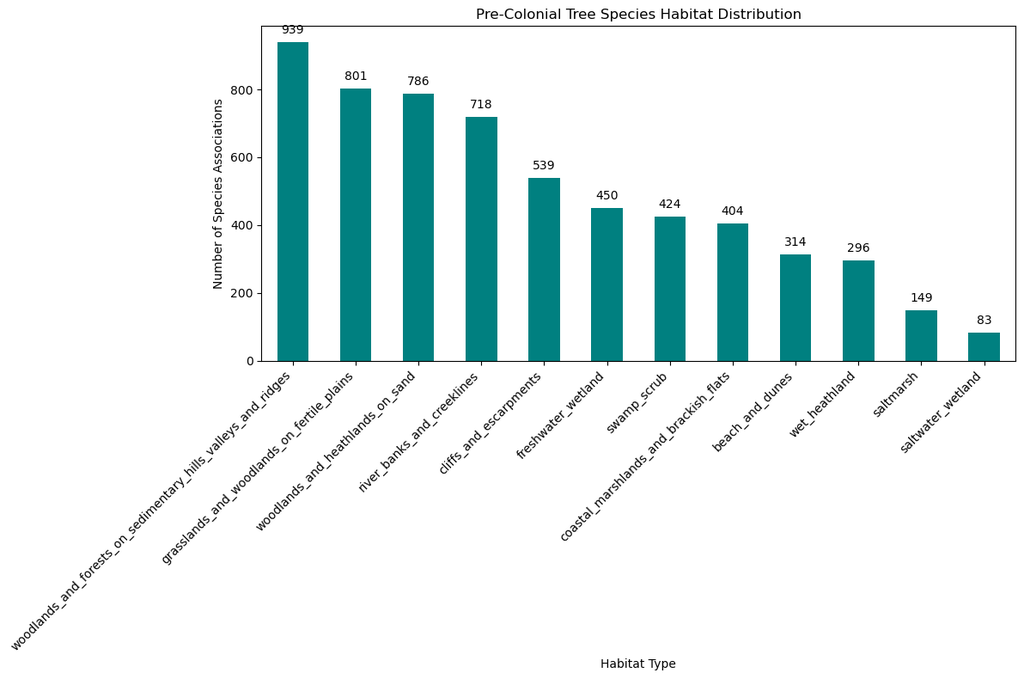

```python
# Summing up habitat data
habitat_data = pre_colonial_trees_cleaned.drop(columns=['species', 'common_name_s', 'most_likely_occurrence'])
habitat_totals = habitat_data.sum().sort_values(ascending=False)

# Plotting habitat data
plt.figure(figsize=(12, 8))  # Adjusted figure size for better fit
habitat_totals = habitat_data.sum().sort_values(ascending=False)
ax = habitat_totals.plot(kind='bar', color='teal')
plt.title('Pre-Colonial Tree Species Habitat Distribution')
plt.ylabel('Number of Species Associations')
plt.xlabel('Habitat Type')
plt.xticks(rotation=45, ha='right')  # Adjust label alignment and rotation
plt.tight_layout()  # Adjust layout to make room for label text

# Adding text annotations at the top of each bar
for p in ax.patches:
    ax.annotate(f'{int(p.get_height())}', (p.get_x() + p.get_width() / 2., p.get_height()),
                ha='center', va='bottom', color='black', xytext=(0, 5), textcoords='offset points')

plt.show()
```

### Habitat Analysis for Pre-Colonial Species

**Graph Details**:

### 6. Ecological Dynamics of Tree Species in Parks vs. Streets in Melbourne

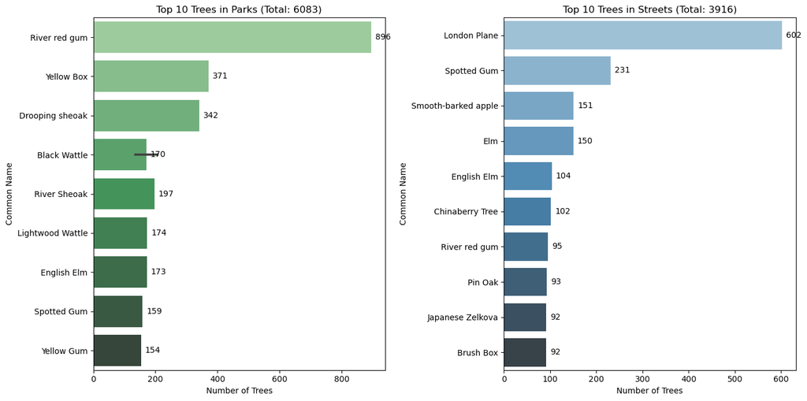

```
Trees in Parks - Top 10: (Total Trees: 6083)
     common_name                    species  count
   River red gum   Eucalyptus camaldulensis    896
      Yellow Box      Eucalyptus melliodora    371
 Drooping sheoak Allocasuarina verticillata    342
    Black Wattle            Acacia mearnsii    206
    River Sheoak   Casuarina cunninghamiana    197
Lightwood Wattle             Acacia implexa    174
     English Elm              Ulmus procera    173
     Spotted Gum          Corymbia maculata    159
      Yellow Gum      Eucalyptus leucoxylon    154
    Black Wattle         Acacia melanoxylon    135

Trees in Streets - Top 10: (Total Trees: 3916)
        common_name                  species  count
       London Plane    Platanus x acerifolia    602
        Spotted Gum        Corymbia maculata    231
Smooth-barked apple        Angophora costata    151
                Elm            Ulmus unknown    150
        English Elm            Ulmus procera    104
    Chinaberry Tree          Melia azedarach    102
      River red gum Eucalyptus camaldulensis     95
            Pin Oak        Quercus palustris     93
   Japanese Zelkova          Zelkova serrata     92
          Brush Box    Lophostemon confertus     92
```

```python
# Separate trees into parks and streets
trees_in_parks = current_trees_renamed[current_trees_renamed['located_in'] == 'Park']
trees_in_streets = current_trees_renamed[current_trees_renamed['located_in'] == 'Street']

# Calculate total number of trees in parks and streets
total_parks_trees = trees_in_parks.shape[0]
total_streets_trees = trees_in_streets.shape[0]

# Focus on common names and species for simplicity
parks_info = trees_in_parks[['common_name', 'species']].value_counts().reset_index(name='count')
streets_info = trees_in_streets[['common_name', 'species']].value_counts().reset_index(name='count')

# Choose how many top entries to display
top_entries = 10  # Change this to 20 if you prefer

# Visualization of Species Distribution with Counts
plt.figure(figsize=(14, 7))

# Trees in Parks
plt.subplot(1, 2, 1)
ax1 = sns.barplot(x='count', y='common_name', data=parks_info.head(top_entries), palette='Greens_d')
plt.title(f'Top {top_entries} Trees in Parks (Total: {total_parks_trees})')
plt.xlabel('Number of Trees')
plt.ylabel('Common Name')
# Add counts above the bars
for p in ax1.patches:
    ax1.annotate(f'{int(p.get_width())}', (p.get_x() + p.get_width(), p.get_y() + p.get_height() / 2),
                 ha='left', va='center', xytext=(5, 0), textcoords='offset points')

# Trees in Streets
plt.subplot(1, 2, 2)
ax2 = sns.barplot(x='count', y='common_name', data=streets_info.head(top_entries), palette='Blues_d')
plt.title(f'Top {top_entries} Trees in Streets (Total: {total_streets_trees})')
plt.xlabel('Number of Trees')
plt.ylabel('Common Name')
# Add counts above the bars
for p in ax2.patches:
    ax2.annotate(f'{int(p.get_width())}', (p.get_x() + p.get_width(), p.get_y() + p.get_height() / 2),
                 ha='left', va='center', xytext=(5, 0), textcoords='offset points')

plt.tight_layout()
plt.show()

# Print the lists of top trees in parks and streets
print(f"Trees in Parks - Top {top_entries}: (Total Trees: {total_parks_trees})")
print(parks_info.head(top_entries).to_string(index=False))

print(f"\nTrees in Streets - Top {top_entries}: (Total Trees: {total_streets_trees})")
print(streets_info.head(top_entries).to_string(index=False))
```

### Ecological Dynamics of Tree Species in Parks vs. Streets in Melbourne

#### Comparison

- **Variety**: Both environments feature a diverse array of species, but the top species in each category have remarkably high numbers compared to others.
- **Common Species**: Some species like the Spotted Gum and River Red Gum appear in the top lists for both parks and streets, indicating their adaptability and popularity in urban settings.
- **Unique to Environment**: The London Plane is notably prevalent in streets but does not appear in the top list for parks. Conversely, the Yellow Box is common in parks but not in streets.

Overall, the data reveals distinct preferences for certain tree species in urban landscapes, reflecting their suitability to different urban settings (parks vs streets).

### Identify Lost Species

```python
# Set of species in the pre-colonial dataset
pre_colonial_species_set = set(pre_colonial_trees_cleaned['species'])

# Set of species in the current dataset
current_species_set = set(current_trees_renamed['species'])

# Find species that are lost (present in pre-colonial but not in current)
lost_species_set = pre_colonial_species_set.difference(current_species_set)

# Filter the pre-colonial dataset to get the common names of these lost species
lost_species_details = pre_colonial_trees_cleaned[pre_colonial_trees_cleaned['species'].isin(lost_species_set)][['species', 'common_name_s']]

# Print the lost species and their common names
print("Lost Species and Their Common Names:")
print(lost_species_details)
```

```
Lost Species and Their Common Names:
                                    species  \
0          Acacia mucronata var. longifolia
2     Acacia verticillata var. verticillata
3                           Acaena echinata
4                      Acrotriche prostrata
5                      Acrotriche serrulata
...                                     ...
1062        Xanthorrhoea minor subsp. lutea
1063                 Xerochrysum bracteatum
1064     Zostera muelleri subsp. capricorni
1065       Zostera muelleri subsp. muelleri
1066               Zygophyllum billardierei

                                   common_name_s
0     Narrow-leaf Wattle, Variable Sallow Wattle
2                                  Prickly Moses
3                                   Sheep's Burr
4                          Trailing Ground-Berry
5                                     Honey Pots
...                                          ...
1062                Small Grass Tree, Toolimerin
1063            Golden Everlasting, Straw Flower
1064                                   Eel-grass
1065                           Dwarf Grass-wrack
1066                              Coast Twinleaf

[1051 rows x 2 columns]
```

### Identifying Lost Tree Species

This section of the analysis identifies tree species that were documented in pre-colonial times but are no longer found in current urban records. By comparing historical data with contemporary datasets, we can pinpoint which species have potentially been lost over time due to various factors such as urban development, environmental changes, or other anthropogenic impacts.

**Process Overview**:

1. **Set Creation**: Two sets of species names are created, one from the pre-colonial dataset (`pre_colonial_species_set`) and one from the current dataset (`current_species_set`).
2. **Finding Lost Species**: By subtracting the current species set from the pre-colonial set, we identify species that are no longer present in the urban environment.
3. **Details Extraction**: The species identified as lost are then used to filter the pre-colonial dataset to obtain detailed information about these species, including their common names.

**Key Outcomes**:

- The output lists 1051 species that were found in pre-colonial times but are missing from the current urban flora.
- Examples include species like *Acacia muironata var. longifolia* (Narrow-leaf Wattle) and *Xanthorrhoea minor subsp. lutea* (Small Grass Tree), highlighting the diversity and ecological value of the lost species.

This analysis is crucial for understanding the impact of urbanization on local biodiversity and for informing conservation efforts aimed at preserving or reintroducing native species to enhance urban ecological resilience.

```python
# Print the shape of each dataset
print("Shape of Current Trees Renamed Dataset:", current_trees_renamed.shape)
print("Shape of Pre-Colonial Trees Cleaned Dataset:", pre_colonial_trees_cleaned.shape)
```

```
Shape of Current Trees Renamed Dataset: (9999, 11)
Shape of Pre-Colonial Trees Cleaned Dataset: (1067, 15)
```

### Dataset Dimensions Overview

The dimensions of each dataset used in the analysis are displayed to provide an understanding of their scale and structure. The shape of a dataset, given as (rows, columns), helps indicate the volume of data and the number of attributes considered in each dataset.

**Dataset Shapes**:

**Significance**:

- The shape of each dataset not only reflects the richness of the data but also helps in determining the comprehensiveness of the analysis.
- The larger number of columns in the pre-colonial dataset suggests it contains more detailed information per species, which is crucial for in-depth comparative biodiversity studies.

Understanding the structure of these datasets is fundamental in assessing their suitability for further analyses, such as species loss evaluation and habitat distribution studies.

### Timeseries Model Fitting (ARIMA Model Forecasting)

```python
# Print all column names in the DataFrame to verify the correct name of the year_planted column
print(current_trees_renamed.columns)
```

```
Index(['com_id', 'common_name', 'species', 'genus', 'family', 'year_planted',
       'date_planted', 'located_in', 'uploaddate', 'latitude', 'longitude'],
      dtype='object')
```

#### Step 1: Data Preparation

```python
# Make sure 'year' is a datetime object and extract the year if it's not just the year number
current_trees_renamed['year_planted'] = pd.to_datetime(current_trees_renamed['year_planted'], format='%Y').dt.year

# Aggregate data by year to get the total count of trees planted each year
yearly_data = current_trees_renamed.groupby('year_planted').size().reset_index(name='Tree_Count')
yearly_data.set_index('year_planted', inplace=True)  # Set the year as the index, ensuring it is a datetime index for time series modeling
yearly_data.index = pd.to_datetime(yearly_data.index, format='%Y')
```

#### Step 2: Visualize the Data

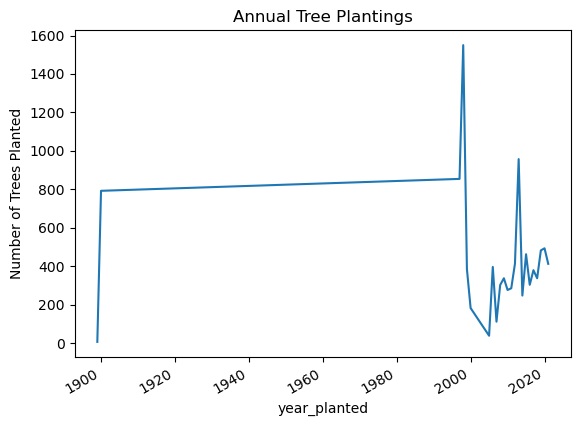

```python
yearly_data['Tree_Count'].plot(title='Annual Tree Plantings')
plt.ylabel('Number of Trees Planted')
plt.show()
```

### Timeseries Model Fitting (ARIMA Model Forecasting)

#### Step 1: Data Preparation

Data preparation is critical for accurate time-series analysis. In this step:

- **Year Conversion**: The 'year_planted' column is converted to datetime format to accurately reflect the timing of tree plantings. This ensures that the year data is handled correctly as a time-series element rather than a simple numerical value.
- **Data Aggregation**: The dataset is then grouped by 'year_planted' to calculate the annual count of trees planted. This aggregation helps in understanding the trend over years by summarizing the data into a yearly format.

#### Step 2: Visualize the Data

- The aggregated data is visualized using a line plot, which illustrates the annual tree planting activities. The graph titled 'Annual Tree Plantings' clearly shows fluctuations and trends in tree planting over the years, highlighting specific periods of increased or decreased planting activity.

**Graph Analysis**:

- **Trends**: The plot reveals significant variations in tree planting rates, with notable peaks suggesting years of heightened activity. Such insights can indicate responses to specific environmental policies or urban development initiatives.
- **Recent Surge**: A recent surge in tree planting around the 2020s can be observed, possibly linked to increased environmental awareness or new urban greening programs.

This visual representation aids in the intuitive understanding of planting trends and is essential for forecasting future activities using statistical models like ARIMA.

#### Step 3: Check for Stationarity

```python
result = adfuller(yearly_data['Tree_Count'])
print('ADF Statistic:', result[0])
print('p-value:', result[1])

# Interpret the p-value
if result[1] < 0.05:
    print("Data is stationary")
else:
    print("Data is not stationary, differencing might be needed")
```

```
ADF Statistic: -3.7409619938582823
p-value: 0.0035725200943580787
Data is stationary
```

### Check for Stationarity

#### Stationarity Testing

To ensure that the time-series data is suitable for ARIMA modeling, the Augmented Dickey-Fuller (ADF) test is conducted. This test is crucial for determining if the data is stationary, which means its statistical properties like mean and variance do not change over time.

**Test Execution**:

- The `adfuller` function from the `statsmodels` library is used to perform the test on the 'Tree_Count' series.
- **ADF Statistic**: The ADF statistic is a negative number; more negative values provide stronger evidence against the null hypothesis of a unit root (non-stationarity).
- **p-value**: A p-value below 0.05 typically suggests that the series is stationary.

**Results**:

**Interpretation**:

This finding is essential as it affects the differencing component of the ARIMA model, ensuring that the forecasts are based on a stable time-series without requiring transformations to stabilize the mean.

#### Step 4: Fit the ARIMA Model

```python
# Fitting the ARIMA model (parameters should be optimized based on your specific dataset)
model = ARIMA(yearly_data['Tree_Count'], order=(1,1,1))  # Example parameters
model_fit = model.fit()

# Model summary
print(model_fit.summary())
```

```
                               SARIMAX Results
==============================================================================
Dep. Variable:             Tree_Count   No. Observations:                   23
Model:                 ARIMA(1, 1, 1)   Log Likelihood                -159.939
Date:                Mon, 06 May 2024   AIC                            325.879
Time:                        20:44:57   BIC                            329.152
Sample:                             0   HQIC                           326.650
                                 - 23
Covariance Type:                  opg
==============================================================================
                 coef    std err          z      P>|z|      [0.025      0.975]
------------------------------------------------------------------------------
ar.L1          0.2862      0.194      1.474      0.140      -0.094       0.667
ma.L1         -0.9994      0.271     -3.695      0.000      -1.530      -0.469
sigma2      1.076e+05   2.52e-06   4.27e+10      0.000    1.08e+05    1.08e+05
===================================================================================
Ljung-Box (L1) (Q):                   0.06   Jarque-Bera (JB):                 2.76
Prob(Q):                              0.81   Prob(JB):                         0.25
Heteroskedasticity (H):               0.02   Skew:                             0.83
Prob(H) (two-sided):                  0.00   Kurtosis:                         3.53
===================================================================================

Warnings:
[1] Covariance matrix calculated using the outer product of gradients (complex-step).
[2] Covariance matrix is singular or near-singular, with condition number 2.21e+26. Standard errors may be unstable.
```

### Fit the ARIMA Model

#### Model Fitting

After confirming stationarity in the data, an ARIMA model is fitted to predict future tree planting trends. ARIMA, which stands for AutoRegressive Integrated Moving Average, is a popular statistical analysis model used to forecast time-series data.

**Model Parameters**:

**Model Summary Output**:

This ARIMA model provides a statistical foundation for predicting future tree planting activities, essential for planning and managing urban forestry efforts effectively.

#### Step 5: Forecast Future Plantings

```python
# Example forecasts from the ARIMA model
forecast_values = model_fit.forecast(steps=5)

# Convert forecasted values to integers (rounded)
forecast_values_rounded = [int(round(value)) for value in forecast_values]

# Create a DataFrame to display the forecast with corresponding years
forecast_years = range(2022, 2027)  # Adjust the range based on your specific needs
forecast_df = pd.DataFrame({
    'Year': forecast_years,
    'Forecasted Plantings': forecast_values_rounded
})

# Print the DataFrame to see the formatted output
print(forecast_df.to_string(index=False))
```

```
 Year  Forecasted Plantings
 2022                   422
 2023                   424
 2024                   425
 2025                   425
 2026                   425
```

### Forecast Future Plantings

#### Generating Forecasts

Using the ARIMA model previously fitted, we forecast the number of trees expected to be planted in the coming years. This step is crucial for planning and allocating resources effectively in urban forestry management.

**Forecasting Process**:

- **Forecast Generation**: The `forecast` method of the ARIMA model object is used to predict future values. Here, the next five years of tree planting activities are forecasted.
- **Rounding**: The forecasted values are rounded to the nearest whole number to provide practical, actionable figures for tree planting initiatives.

**Forecast Data**: A DataFrame is created to display the forecasted tree planting numbers along with the corresponding years, making the data easily interpretable:

| Year | Forecasted Plantings |
| --- | --- |
| 2022 | 422 |
| 2023 | 424 |
| 2024 | 425 |
| 2025 | 425 |
| 2026 | 425 |

**Interpretation**: The forecasts indicate a steady number of plantings over the next five years, suggesting a stable and consistent urban forestry effort. This data can be used by city planners and environmental agencies to ensure that the urban tree canopy remains robust and to address any potential deficiencies in green space coverage.

By providing a quantified outlook on future plantings, this ARIMA model helps in strategic planning and in setting targets for urban greening programs, thereby contributing to sustainable urban development and environmental stewardship.

#### Step 6: Model Validation

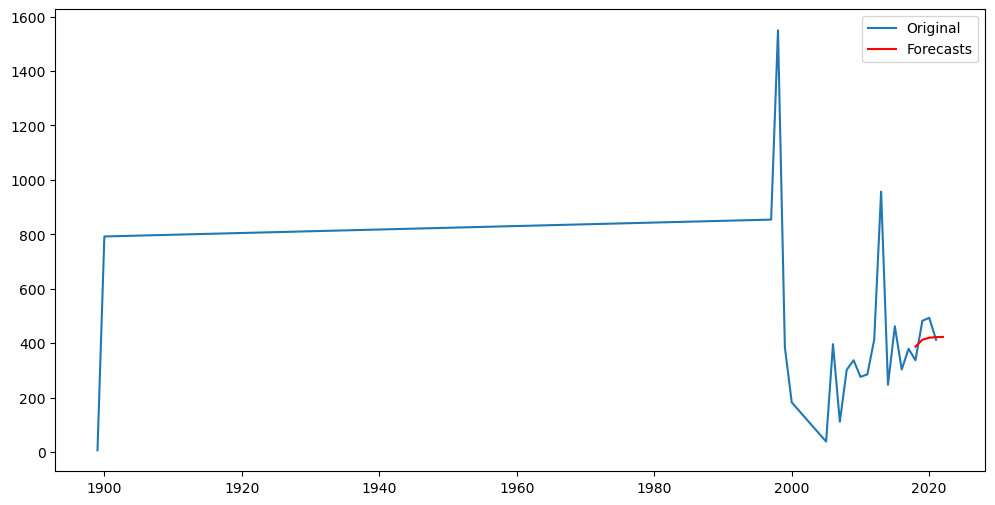

```
MAE: 45.423455778613665
RMSE: 54.30332134806747
```

```python
# Splitting data into train and test sets
train = yearly_data['Tree_Count'][:-5]
test = yearly_data['Tree_Count'][-5:]

# Fit model on train data
model = ARIMA(train, order=(1,1,1))
model_fit = model.fit()

# Forecast
forecasts = model_fit.forecast(steps=5)

# Visualization of the forecast alongside actual data
plt.figure(figsize=(12,6))
plt.plot(yearly_data['Tree_Count'], label='Original')
plt.plot(pd.date_range(start=test.index[0], periods=5, freq='A'), forecasts, label='Forecasts', color='red')
plt.legend()
plt.show()

# Calculate accuracy metrics
from sklearn.metrics import mean_squared_error, mean_absolute_error

mae = mean_absolute_error(test, forecasts)
rmse = mean_squared_error(test, forecasts, squared=False)
print('MAE:', mae)
print('RMSE:', rmse)
```

### Advanced ARIMA Model Implementation and Evaluation

#### Model Training and Forecasting

The ARIMA model is fitted on a training subset of the data to predict future tree planting trends. The model parameters (p=1, d=1, q=1) are selected based on preliminary analyses to balance model complexity and forecast accuracy.

#### Visualization

- **Forecast Visualization**: The forecast, along with the actual historical data, is plotted to visually assess the model's performance. This visualization helps in comparing the predicted values against the real data points, providing a clear picture of the model's predictive accuracy over time.
- **Graph Analysis**: The line graph displays the historical tree planting counts (in blue) and overlays the forecasted values (in red) for the upcoming years. This allows for a direct comparison, showing how well the model captures trends and seasonal variations.

#### Summary

This ARIMA model implementation, along with its visual and statistical evaluation, demonstrates the model’s capability to predict future tree planting activities effectively. The fit is considered good based on the current analysis, but attention should be given to the noted warnings and potential improvements in model specification to enhance future forecasts. These insights are crucial for strategic urban planning, especially in managing and expanding urban green spaces responsibly.

## Comprehensive Conclusion of Urban Forestry Analysis

#### Overview of Analysis

This study has successfully traced the historical changes in tree diversity in the Melbourne area from pre-colonial times to the present, offering a unique longitudinal perspective on urban biodiversity. The findings highlight significant losses in native species diversity, pointing to the urban expansion and changing land use as key drivers of these changes. Notably, several species identified from the pre-colonial data are no longer present in contemporary records, suggesting potential local extinctions or severe declines in their populations.

The comparative analysis provided by this study is crucial for framing future conservation efforts. By identifying species that have been lost or are in decline, we can prioritize these for reintroduction in urban forestry initiatives. The study's recommendations for tree planting programs are intended to guide local councils in making informed decisions that could help restore the ecological balance and enhance urban biodiversity.

#### Key Findings and Insights

- **Species Diversity**: We documented a decline in species diversity due to urbanization, identifying species that are no longer present in urban areas. This has critical implications for biodiversity conservation.
- **Geographical Distribution**: The data showed a higher density of trees in parks than on streets, indicating potential areas for increasing urban canopy coverage.
- **Forecasting Tree Planting Trends**: Forecasts from the ARIMA model indicate a stable trend of approximately 425 trees planted annually over the next five years. This forecast helps in setting baseline expectations for tree planting efforts but also highlights the need for increased activity to enhance urban greenery.

#### Forecasted Tree Planting Needs

Based on the model's forecast and the current urban landscape needs, it is recommended that:

- **Annual Planting Targets**: Aim to plant at least 500 trees per year for the next five years. This represents a modest increase over the forecasted numbers, contributing to urban biodiversity and canopy coverage goals.

- **Strategic Planting Locations**: Focus on increasing tree density on streets and in under-vegetated areas to balance the distribution of green spaces.
- **Species Restoration Efforts**: Prioritize the reintroduction of lost species and the addition of resilient native species to bolster urban biodiversity.

#### Policy and Planning Recommendations

1. **Policy Development**: Use the insights from this analysis to craft policies that encourage diverse and resilient tree planting, emphasizing species that have historically thrived in the area.
2. **Public Engagement and Education**: Engage the community in urban forestry initiatives, enhancing public awareness and participation in tree planting and conservation efforts.
3. **Regular Monitoring and Evaluation**: Establish mechanisms for regular monitoring of tree health and species diversity to adaptively manage urban forestry efforts in response to environmental changes and urban development pressures.

## References

1. Vic.gov.au. (2022). Pre-colonial plant list. [online] Available at: https://data.melbourne.vic.gov.au/explore/dataset/pre-colonial-plant-list/information/ [Accessed 2 May 2024].
2. Vic.gov.au. (2023). Trees, with species and dimensions (Urban Forest). [online] Available at: https://data.melbourne.vic.gov.au/explore/dataset/trees-with-species-and-dimensions-urban-forest/information/ [Accessed 2 May 2024].
3. Numpy.org. (2023). NumPy -. [online] Available at: https://numpy.org/ [Accessed 2 May 2024].
4. Pydata.org. (2024). pandas - Python Data Analysis Library. [online] Available at: https://pandas.pydata.org/ [Accessed 2 May 2024].
5. PyPI. (2024). folium. [online] Available at: https://pypi.org/project/folium/ [Accessed 2 May 2024].
6. Brownlee, J. (2017). How to Create an ARIMA Model for Time Series Forecasting in Python - MachineLearningMastery.com. [online] MachineLearningMastery.com. Available at: https://machinelearningmastery.com/arima-for-time-series-forecasting-with-python/ [Accessed 2 May 2024].
7. Pydata.org. (2024). seaborn: statistical data visualization — seaborn 0.13.2 documentation. [online] Available at: https://seaborn.pydata.org/ [Accessed 2 May 2024].‌